# Analyzing PML Activity Data Set

YSB

September 15, 2017

# Preliminary Analysis of the data

First, let’s load packages and read the dataset from the files. We assume dataset files are located in the same directory as this markdown document.

```r
#Load Required Packages
library(e1071)
```

```r
library(ggplot2)
dtrain = read.csv("./pml-training.csv")
dtest = read.csv("./pml-testing.csv")

print("No of missing values:")
```

```
## [1] "No of missing values:"
```

```r
missing_values_cnt = sum(is.na(dtrain))
print(missing_values_cnt)
```

```
## [1] 1287472
```

```r
print("Total No of values:")
```

```
## [1] "Total No of values:"
```

```r
total_values_cnt = dim(dtrain)[1]*dim(dtrain)[2]
print(total_values_cnt)
```

```
## [1] 3139520
```

```r
print("Percentage of missing data:")
```

```
## [1] "Percentage of missing data:"
```

```r
print(100*missing_values_cnt/total_values_cnt)
```

```
## [1] 41.00856
```

```r
print("Percentage of observations with complete data")
```

```
## [1] "Percentage of observations with complete data"
```

```r
print(100*sum(complete.cases(dtrain))/dim(dtrain)[1])
```

```
## [1] 2.069106
```

```r
dtrain = dtrain[,-1]
dtest = dtest[,-1]
```

The first column “X” in the dataset is just an index and hence, we remove it from further analysis. Also, as seen above, the dataset has significant amount of missing values and hence, we will impute the missing values by using the mean value of the respective columns. But before that, we analyze which columns are important with the given data so that we impute only columns that we need. This would save us unnecessary computations.

# Analysis of importance of each column using Information Gain

We calculate the information gain for each column to find out important columns. We then plot the information gain given by each column in decreasing order of the gain.

```r
library(FSelector)
```

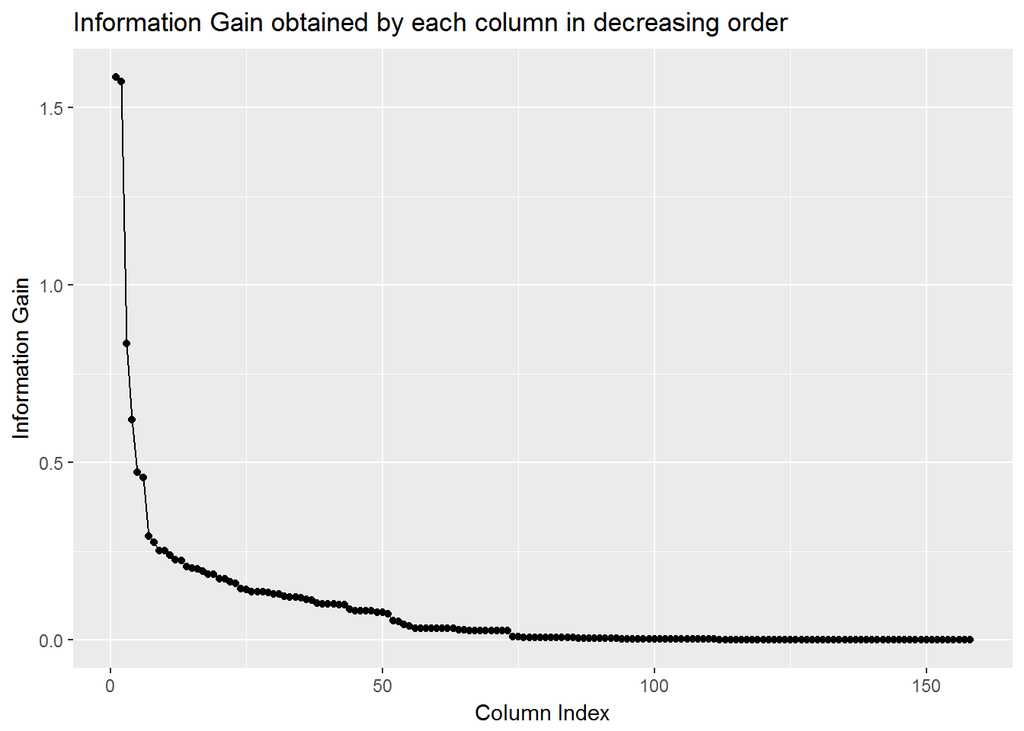

```r
IG = information.gain(classe~.,data=dtrain)
qplot(x=1:dim(IG)[1],y=IG[cutoff.k(IG,k=dim(IG)[1]),])+geom_line()+labs(title="Information Gain obtained by each column in decreasing order")+xlab("Column Index")+ylab("Information Gain")
```

```r
igFeatures = cutoff.k(IG,k=20)
training = dtrain[c(igFeatures,"classe")]
print("No of missing values:")
```

```
## [1] "No of missing values:"
```

```r
sum(is.na(training))
```

```
## [1] 0
```

From the above plot, we can see that 20 columns are good enough w.r.t. information gain. Further columns do not add much information. Hence, we select top 20 columns for further processing.

Also, As we can see, there are no missing values in the reduced dataset and hence, this can save us from effort of imputing columns. We proceed with dividing the dataset for further analysis.